# Characterization of AS events in irCLIPv2 and Re-CLIP dataset from EGF timecourse for HNRNPC and UPF1

Luca Ducoli

This is the pipeline used to analyze the irCLIPv2 and Re-CLIP datasets of UPF1 and HNRNPC from EGF time course. HNRNPC and UPF1 irCLIPv2 was performed at 0, 15, 30, and 60min EGF stimulation. HNRNPC and UPF1 irCLIPv2 after the knockdown of the UPF1 and HNRNPC were performed at 0 and 60min EGF stimulation. HNRNPC-UPF1 Re-CLIP was performed at 0, 30, 60min EGF stimualtion. The experiments were performed in duplicates for each time point in A431 cells.

# 1. Characterization of AS events

```r
library(tidyverse)
library(Repitools)
library(AnnotationHub)
library(AnnotationDbi)
library(ggplot2)
library(plyranges)
library(GenomicRanges)
library(gintools)
library(rtracklayer)
library(EnrichedHeatmap)
library(circlize)
library(caTools)
library(cliProfiler)
library(paletteer)
library(gridExtra)
library(NbClust)
library(RColorBrewer)
library(ChIPpeakAnno)
library(data.table)
library(BRGenomics)
library(DESeq2)
library(ggpmisc)
library(eulerr)
library(memes)
library(BSgenome.Hsapiens.UCSC.hg38)
library(universalmotif)
library(SLIMFinderR)
library(ggraph)
library(plyr)
library(ggpubr)
```

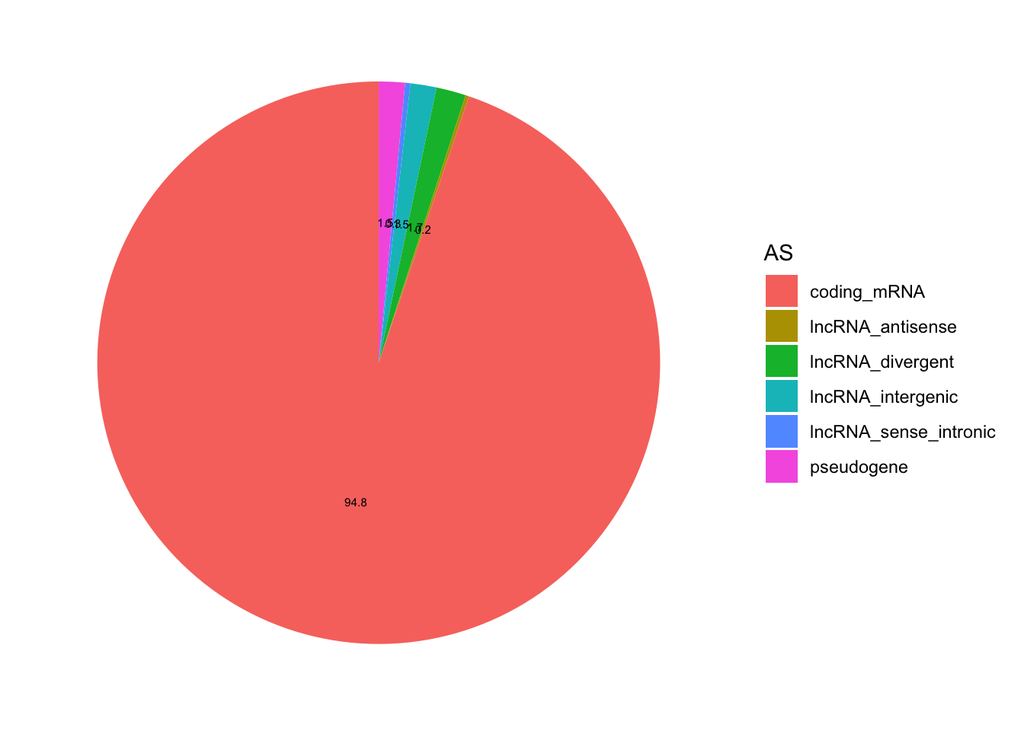

```r
#Get transcript names from rMATs output
gtf <- rtracklayer::import('~/Documents/Postdoc/PD_Projects/3_irCLIP-RNP/MS/siRNA_EGF_SG/2_EGF/8_DTE_analysis/0_UPF1_HNRNPC/1_DTE/Genome/gencode.v39.annotation.gtf')
gtf_df=as.data.frame(gtf)

AS_event <- read.delim("~/Documents/Postdoc/PD_Projects/3_irCLIP-RNP/MS/siRNA_EGF_SG/2_EGF/8_DTE_analysis/0_UPF1_HNRNPC/0_Overlap/HNRNPC_UPF1_ASevents.txt", header = TRUE)
AS_event <- AS_event %>% mutate("gene_id" = sapply(strsplit(AS_event$region, "_"), function(x) x[1]),
                                "gene_name"= sapply(strsplit(AS_event$region, "_"), function(x) x[2]),
                                "chr"= sapply(strsplit(AS_event$region, "_"), function(x) x[3]),
                                "strand"= sapply(strsplit(AS_event$region, "_"), function(x) x[4]),
                                "start" = sapply(strsplit(AS_event$region, "_"), function(x) x[5]),
                                "end"= sapply(strsplit(AS_event$region, "_"), function(x) x[6])) %>% dplyr::select(c(region,chr,start,end, strand, gene_id, gene_name, AS))

gene.info <- read.delim("/Users/lducoli/Documents/Postdoc/PD_Projects/3_irCLIP-RNP/Seq/4_EGF_tc/0_Annotation/0_F6_CAT.gene.info.tsv.txt", header = TRUE)

AS_event$geneID <- gsub("\\..*", "", AS_event$gene_id)
AS_event <- merge(AS_event, gene.info[,1:4], by = "geneID", all.x = TRUE)
AS_event$CAT_geneClass[AS_event$geneID %in% c("ENSG00000273559", "ENSG00000183793", "ENSG00000183889",
                                              "ENSG00000241322", "ENSG00000261740", "ENSG00000265190", "ENSG00000265354", "ENSG00000265808",
                                              "ENSG00000269335", "ENSG00000270647", "ENSG00000277149", "ENSG00000277791", "ENSG00000278540",
                                              "ENSG00000283228", "ENSG00000284626", "ENSG00000284770", "ENSG00000285106", "ENSG00000285130",
                                              "ENSG00000286001", "ENSG00000286192", "ENSG00000288683")] <- "coding_mRNA"
AS_event$CAT_geneClass[AS_event$geneID == "ENSG00000288663"] <- "lncRNA_sense_intronic"
AS_event$CAT_geneClass[AS_event$geneID %in% c("ENSG00000224817", "ENSG00000230724", "ENSG00000250920", "ENSG00000255052", "ENSG00000268460",
                                              "ENSG00000275464", "ENSG00000285756")] <- "lncRNA_intergenic"
AS_event$CAT_geneClass[AS_event$geneID %in% c("ENSG00000225151", "ENSG00000226210", "ENSG00000244306", "ENSG00000276291",
                                              "ENSG00000286156")] <- "pseudogene"

#Pie Chart
regionRes <- unique(AS_event %>% dplyr::select(geneID, CAT_geneClass)) %>% dplyr::count(CAT_geneClass)
regionRes$AS <- factor(regionRes$CAT_geneClass)

regionRes <- regionRes %>%
  arrange(desc(AS)) %>%
  mutate(prop = round((n / sum(regionRes$n))*100,1)) %>%
  mutate(ypos = cumsum(prop)- 0.5*prop )

piechart <- ggplot(regionRes, aes(x="", y=prop, fill=AS))+ geom_bar(width = 1, stat = "identity") +
    coord_polar("y", start=0) +
  theme_minimal()+
  theme(
  axis.title.x = element_blank(),
  axis.title.y = element_blank(),
  panel.border = element_blank(),
  panel.grid=element_blank(),
  axis.ticks = element_blank(),
  plot.title=element_text(size=14, face="bold")
  )+
  theme(axis.text.x=element_blank()) +
  geom_text(aes(y = ypos, label = prop), color = "black", size=2)

piechart
```

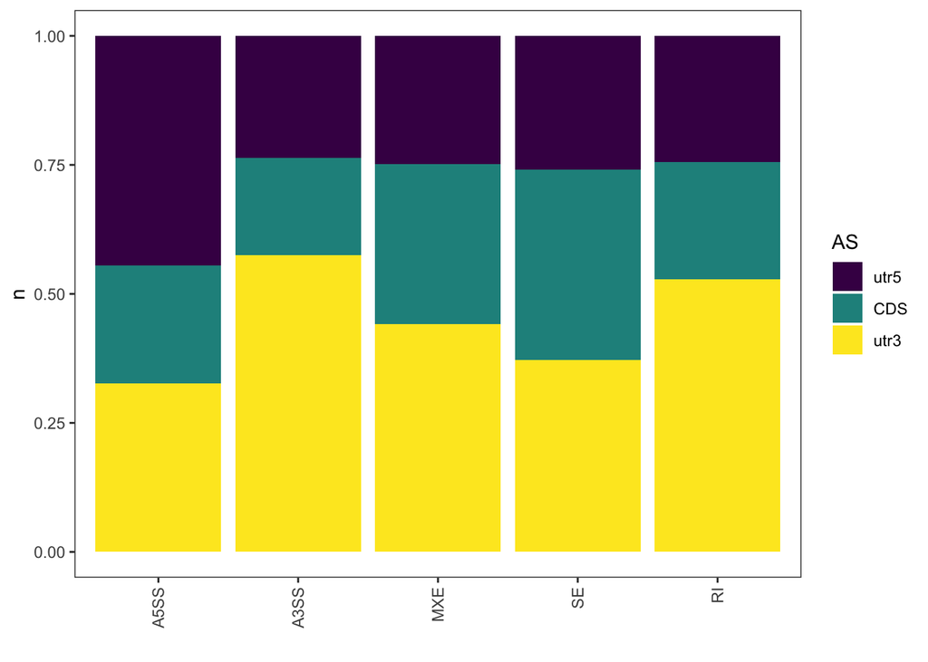

```r
#Subset to protein coding
AS_event <- subset(AS_event, CAT_geneClass == "coding_mRNA")
write.table(AS_event, "~/Documents/Postdoc/PD_Projects/3_irCLIP-RNP/Seq/4_EGF_tc/4_Visualization/1_Distribution/PC_AS_events.txt", quote = F, sep = "\t")

#Pie chart genomic regions
region.gr <- GRanges(AS_event[,grep("chr", colnames(AS_event))], IRanges(start=as.numeric(AS_event[,grep("start", colnames(AS_event))]), end=as.numeric(AS_event[,grep("end", colnames(AS_event))]),  names = AS_event[,grep("region", colnames(AS_event))]), strand = AS_event[,grep("strand", colnames(AS_event))], AS_event = AS_event[,grep("AS", colnames(AS_event))])

txdb <- loadDb("~/Documents/Postdoc/PD_Projects/3_irCLIP-RNP/Seq/1_Subzones/0_Annotation/gencode.v39.annotation")

dist <- genomicElementDistribution(region.gr, TxDb = txdb, promoterRegion=c(upstream=0, downstream=0), geneDownstream=c(upstream=0, downstream=0), ignore.strand = FALSE, plot = FALSE)

region_anno <- as.data.frame(mcols(dist$peaks))
region_anno$Exons <- ifelse(region_anno$Exons == "otherExon", "CDS", region_anno$Exons)
regionRes2 <- region_anno %>% group_by(AS_event) %>% dplyr::count(Exons)
regionRes2$AS <- factor(regionRes2$Exons)
regionRes2$AS <- factor(regionRes2$AS, levels = c("utr5", "CDS", "utr3"))
regionRes2$AS_event <- factor(regionRes2$AS_event, levels = c("A5SS", "A3SS", "MXE", "SE", "RI"))

stacked <- ggplot(regionRes2, aes(fill=AS, y=n, x=AS_event)) +
    geom_bar(position="fill", stat="identity") +
      scale_fill_viridis(discrete = T) +
    theme_bw() +
  theme(panel.grid.major = element_blank(), panel.grid.minor = element_blank(),
        axis.line = element_blank())+
    xlab("") + theme(axis.text.x = element_text(angle = 90, vjust = 0.5, hjust=1))

stacked
```

```r
#Get the transcripts
AS_event_tx <- merge(AS_event %>% dplyr::select(region,gene_id,AS), gtf_df[gtf_df$type == "transcript",], by = "gene_id") %>% dplyr::select(c(seqnames,start,end,transcript_id, strand, gene_id, gene_name, AS))

AS_event_bed <- AS_event %>% dplyr::select(chr, start, end, strand, region, gene_id, AS)
AS_event_tx_bed <- AS_event_tx %>% dplyr::select(seqnames, start, end, strand, transcript_id, gene_id)

#bedtools to get regions inside transcripts
AS_event_tx2 <- bedtoolsr::bt.intersect(AS_event_bed, AS_event_tx_bed, loj = TRUE)
AS_event_tx2 <- unique(AS_event_tx2)

colnames(AS_event_tx2) <- c("AS_chr", "AS_start", "AS_end", "AS_strand", "AS_region", "AS_geneID", "AS_event", "TX_chr", "TX_start", "TX_end", "TX_strand", "TX_id", "TX_geneID")
AS_event_tx2 <- AS_event_tx2 %>% mutate(geneIDmatch = case_when(AS_geneID != TX_geneID  ~ "0",AS_geneID == TX_geneID ~ "1"))
AS_event_tx2 <- subset(AS_event_tx2, geneIDmatch > 0)
```

```r
# Save the plot as pdf
pdf("~/Documents/Postdoc/PD_Projects/3_irCLIP-RNP/Seq/4_EGF_tc/4_Visualization/1_Distribution/Piechart_anno_HNRNPC_UPF1_AS_region.pdf",  height=5, width=5)
piechart
dev.off()

pdf("~/Documents/Postdoc/PD_Projects/3_irCLIP-RNP/Seq/4_EGF_tc/4_Visualization/1_Distribution/Stacked_anno_HNRNPC_UPF1_AS_region.pdf",  height=5, width=3)
stacked
dev.off()
```

# 2. Check the distribution of RT stops for HNRNPC and UPF1 and re-CLIP data

##Percentage across AS events In order to identify where on the AS transcripts the co-binding events between UPF1 and HNRNPC are happening, we analyzed first the percentage of the RT stop location across several genomic features (5’UTR, exon, intron, 3’UTR).

[figure not shown]

```r
#Get annotation
gff_anno <- rtracklayer::import.gff3('~/Documents/Postdoc/PD_Projects/3_irCLIP-RNP/Seq/0_Annotation/gencode.v39.annotation.gff3')

#Get normalized bigwigfiles
egf_granges <- function(rbp, tp) {
setwd("~/Documents/Postdoc/PD_Projects/3_irCLIP-RNP/Seq/4_EGF_tc/3_Bigwig_sum")
bw.p <- rtracklayer::import.bw(paste(rbp, "A431", tp, "merged.p.scaleddewseq.bw", sep = "_"))
bw.m <- rtracklayer::import.bw(paste(rbp, "A431", tp, "merged.m.scaleddewseq.bw", sep = "_"))

strand(bw.p) <- "+"
strand(bw.m) <- "-"

bw <- bind_ranges(bw.p, bw.m)
bw$timepoint <- gsub("_HMW", "", tp)
bw$rbp <- rbp
bw$score <- NULL
return(bw)
}

bw.EGF0.HNRNPC <- egf_granges("HNRNPC", "EGF0")
bw.EGF15.HNRNPC <- egf_granges("HNRNPC", "EGF15")
bw.EGF30.HNRNPC <- egf_granges("HNRNPC", "EGF30")
bw.EGF60.HNRNPC <- egf_granges("HNRNPC", "EGF60")

bw.EGF0.UPF1 <- egf_granges("UPF1", "EGF0_HMW")
bw.EGF15.UPF1 <- egf_granges("UPF1", "EGF15_HMW")
bw.EGF30.UPF1 <- egf_granges("UPF1", "EGF30_HMW")
bw.EGF60.UPF1 <- egf_granges("UPF1", "EGF60_HMW")

#Get normalized bigwigfiles from reclip
egf_granges <- function(rbp, tp) {
setwd("~/Documents/Postdoc/PD_Projects/3_irCLIP-RNP/Seq/6_reclip-EGF_tcupf1/3_Bigwig_sum")
bw.p <- rtracklayer::import.bw(paste(rbp, "A431_hnC", tp, "merged.p.scaleddewseq.bw", sep = "_"))
bw.m <- rtracklayer::import.bw(paste(rbp, "A431_hnC", tp, "merged.m.scaleddewseq.bw", sep = "_"))

strand(bw.p) <- "+"
strand(bw.m) <- "-"

bw <- bind_ranges(bw.p, bw.m)
bw$timepoint <- gsub("_HMW", "", tp)
bw$rbp <- paste("re", rbp, sep = "_")
bw$score <- NULL
return(bw)
}

bw.reEGF0.IgG <- egf_granges("IgG", "EGF0")
bw.reEGF30.IgG <- egf_granges("IgG", "EGF30")
bw.reEGF60.IgG <- egf_granges("IgG", "EGF60")

bw.reEGF0.UPF1 <- egf_granges("UPF1", "EGF0_HMW")
bw.reEGF30.UPF1 <- egf_granges("UPF1", "EGF30_HMW")
bw.reEGF60.UPF1 <- egf_granges("UPF1", "EGF60_HMW")

#Subset to AS transcripts
gr.tx <- GRanges(AS_event_tx2[,grep("^TX_chr$", colnames(AS_event_tx2))],
                  IRanges(start=AS_event_tx2[,grep("^TX_start$", colnames(AS_event_tx2))],
                          end=AS_event_tx2[,grep("^TX_end$", colnames(AS_event_tx2))]),
                  tx_name = AS_event_tx2[,grep("^TX_id$", colnames(AS_event_tx2))],
                  strand = AS_event_tx2[,grep("^TX_strand$", colnames(AS_event_tx2))],
                  gene_name = AS_event_tx2[,grep("^TX_geneID$", colnames(AS_event_tx2))],
                width_region = AS_event_tx2[,grep("^TX_end$", colnames(AS_event_tx2))]-AS_event_tx2[,grep("^TX_start$", colnames(AS_event_tx2))],
                AS = AS_event_tx2[,grep("^AS_event$", colnames(AS_event_tx2))])
gr.tx <- unique_granges(gr.tx)

get_density <- function(gr.tx, event) {
  gr.tx <- subset(gr.tx, AS == event)

  bw.EGF0.HNRNPC <- find_overlaps(bw.EGF0.HNRNPC, gr.tx)
  mcols(bw.EGF0.HNRNPC) <- mcols(bw.EGF0.HNRNPC)[c(1,2,6)]
  bw.EGF0.HNRNPC <- unique_granges(bw.EGF0.HNRNPC)

  bw.EGF15.HNRNPC <- find_overlaps(bw.EGF15.HNRNPC, gr.tx)
  mcols(bw.EGF15.HNRNPC) <- mcols(bw.EGF15.HNRNPC)[c(1,2,6)]
  bw.EGF15.HNRNPC <- unique_granges(bw.EGF15.HNRNPC)

  bw.EGF30.HNRNPC <- find_overlaps(bw.EGF30.HNRNPC, gr.tx)
  mcols(bw.EGF30.HNRNPC) <- mcols(bw.EGF30.HNRNPC)[c(1,2,6)]
  bw.EGF30.HNRNPC <- unique_granges(bw.EGF30.HNRNPC)

  bw.EGF60.HNRNPC <- find_overlaps(bw.EGF60.HNRNPC, gr.tx)
  mcols(bw.EGF60.HNRNPC) <- mcols(bw.EGF60.HNRNPC)[c(1,2,6)]
  bw.EGF60.HNRNPC <- unique_granges(bw.EGF60.HNRNPC)

  bw.EGF0.UPF1 <- find_overlaps(bw.EGF0.UPF1, gr.tx)
  mcols(bw.EGF0.UPF1) <- mcols(bw.EGF0.UPF1)[c(1,2,6)]
  bw.EGF0.UPF1 <- unique_granges(bw.EGF0.UPF1)

  bw.EGF15.UPF1 <- find_overlaps(bw.EGF15.UPF1, gr.tx)
  mcols(bw.EGF15.UPF1) <- mcols(bw.EGF15.UPF1)[c(1,2,6)]
  bw.EGF15.UPF1 <- unique_granges(bw.EGF15.UPF1)

  bw.EGF30.UPF1 <- find_overlaps(bw.EGF30.UPF1, gr.tx)
  mcols(bw.EGF30.UPF1) <- mcols(bw.EGF30.UPF1)[c(1,2,6)]
  bw.EGF30.UPF1 <- unique_granges(bw.EGF30.UPF1)

  bw.EGF60.UPF1 <- find_overlaps(bw.EGF60.UPF1, gr.tx)
  mcols(bw.EGF60.UPF1) <- mcols(bw.EGF60.UPF1)[c(1,2,6)]
  bw.EGF60.UPF1 <- unique_granges(bw.EGF60.UPF1)

  bw.reEGF0.IgG <- find_overlaps(bw.reEGF0.IgG, gr.tx)
  mcols(bw.reEGF0.IgG) <- mcols(bw.reEGF0.IgG)[c(1,2,6)]
  bw.reEGF0.IgG <- unique_granges(bw.reEGF0.IgG)

  bw.reEGF30.IgG <- find_overlaps(bw.reEGF30.IgG, gr.tx)
  mcols(bw.reEGF30.IgG) <- mcols(bw.reEGF30.IgG)[c(1,2,6)]
  bw.reEGF30.IgG <- unique_granges(bw.reEGF30.IgG)

  bw.reEGF60.IgG <- find_overlaps(bw.reEGF60.IgG, gr.tx)
  mcols(bw.reEGF60.IgG) <- mcols(bw.reEGF60.IgG)[c(1,2,6)]
  bw.reEGF60.IgG <- unique_granges(bw.reEGF60.IgG)

  bw.reEGF0.UPF1 <- find_overlaps(bw.reEGF0.UPF1, gr.tx)
  mcols(bw.reEGF0.UPF1) <- mcols(bw.reEGF0.UPF1)[c(1,2,6)]
  bw.reEGF0.UPF1 <- unique_granges(bw.reEGF0.UPF1)

  bw.reEGF30.UPF1 <- find_overlaps(bw.reEGF30.UPF1, gr.tx)
  mcols(bw.reEGF30.UPF1) <- mcols(bw.reEGF30.UPF1)[c(1,2,6)]
  bw.reEGF30.UPF1 <- unique_granges(bw.reEGF30.UPF1)

  bw.reEGF60.UPF1 <- find_overlaps(bw.reEGF60.UPF1, gr.tx)
  mcols(bw.reEGF60.UPF1) <- mcols(bw.reEGF60.UPF1)[c(1,2,6)]
  bw.reEGF60.UPF1 <- unique_granges(bw.reEGF60.UPF1)

  bw.EGF <- bind_ranges(bw.EGF0.HNRNPC, bw.EGF15.HNRNPC, bw.EGF30.HNRNPC, bw.EGF60.HNRNPC,
                        bw.EGF0.UPF1,bw.EGF15.UPF1,bw.EGF30.UPF1,bw.EGF60.UPF1,
                        bw.reEGF0.IgG, bw.reEGF30.IgG, bw.reEGF60.IgG, bw.reEGF0.UPF1, bw.reEGF30.UPF1, bw.reEGF60.UPF1)

  #UTR5
  UTR5 <- gff_anno[gff_anno$type == "five_prime_UTR"]
  UTR5_profile <- windowProfile(bw.EGF, UTR5)
  UTR5_profile$Peaks$type <- "UTR5"
  UTR5_profile$Peaks <- subset(UTR5_profile$Peaks, window_map != 3)

  #Exon
  exon <- gff_anno[gff_anno$type == "CDS"]
  exon_profile <- windowProfile(bw.EGF, exon)
  exon_profile$Peaks$type <- "exon"
  exon_profile$Peaks <- subset(exon_profile$Peaks, window_map != 3)

  #Intron
  intron_profile <-  intronProfile(bw.EGF, annotation = "~/Documents/Postdoc/PD_Projects/3_irCLIP-RNP/Seq/0_Annotation/gencode.v39.annotation_protcoding.gff3")
  intron_profile$Peaks$type <- "intron"
  intron_profile$Peaks <- subset(intron_profile$Peaks, Intron_map != 3)

  #UTR3
  UTR3 <- gff_anno[gff_anno$type == "three_prime_UTR"]
  UTR3_profile <- windowProfile(bw.EGF, UTR3)
  UTR3_profile$Peaks$type <- "UTR3"
  UTR3_profile$Peaks <- subset(UTR3_profile$Peaks, window_map != 3)

  df <- data.frame("Position" = c(UTR5_profile$Peaks$window_map, exon_profile$Peaks$window_map, intron_profile$Peaks$Intron_map, UTR3_profile$Peaks$window_map), "location" = c(UTR5_profile$Peaks$type, exon_profile$Peaks$type, intron_profile$Peaks$type, UTR3_profile$Peaks$type), "group" = c(UTR5_profile$Peaks$timepoint, exon_profile$Peaks$timepoint, intron_profile$Peaks$timepoint, UTR3_profile$Peaks$timepoint), "rbp" = c(UTR5_profile$Peaks$rbp, exon_profile$Peaks$rbp, intron_profile$Peaks$rbp, UTR3_profile$Peaks$rbp))
  df$AS <- event
  return(df)
}

A5SS_pfl <- get_density(gr.tx, "A5SS")
A3SS_pfl <- get_density(gr.tx, "A3SS")
SE_pfl <- get_density(gr.tx, "SE")
MXE_pfl <- get_density(gr.tx, "MXE")
RI_pfl <- get_density(gr.tx, "RI")

saveRDS(RI_pfl, "~/Documents/Postdoc/PD_Projects/3_irCLIP-RNP/Seq/4_EGF_tc/4_Visualization/1_Distribution/RI_profile.rds")

result <- rbind(A5SS_pfl, A3SS_pfl, SE_pfl, MXE_pfl, RI_pfl)

#Calculate the percentage for each genomic feature
percentage_rt <- function(as_df, event) {
  df2 <- as_df %>%
    group_by(location, group, rbp) %>%
    summarise_at(vars(Position), funs(sum(., na.rm=TRUE)))

  df3 <- as_df %>%
    group_by(group, rbp) %>%
    summarise_at(vars(Position), funs(sum(., na.rm=TRUE)))

  result <- df2 %>%
    left_join(df3, by = c("group", "rbp")) %>%
    mutate(relative_position = Position.x / Position.y) %>%
    select(location, group, rbp, relative_position)
  result$type <- paste(result$group, result$rbp, sep = "_")
  result$location <- factor(result$location, levels = c("UTR5", "exon", "intron", "UTR3"))
  result$type <- factor(result$type, levels = c( "EGF0_HNRNPC", "EGF15_HNRNPC", "EGF30_HNRNPC", "EGF60_HNRNPC", "EGF0_UPF1",
                                                "EGF15_UPF1", "EGF30_UPF1", "EGF60_UPF1", "EGF0_re_IgG", "EGF30_re_IgG",  "EGF60_re_IgG",
                                                "EGF0_re_UPF1", "EGF30_re_UPF1","EGF60_re_UPF1"))
   result$AS <- event
  return(result)
}

A5SS_res <- percentage_rt(A5SS_pfl, "A5SS")
A3SS_res <- percentage_rt(A3SS_pfl, "A3SS")
SE_res <- percentage_rt(SE_pfl, "SE")
MXE_res <- percentage_rt(MXE_pfl, "MXE")
RI_res <- percentage_rt(RI_pfl, "RI")

all_res <- rbind(A5SS_res, A3SS_res, SE_res, MXE_res, RI_res)

result2 <- all_res %>%
    group_by(type, location) %>%
    summarise_at(vars(relative_position), funs(mean(., na.rm=TRUE)))

result2 <- dcast(result2 %>% dplyr::select(type, location, relative_position), type ~ location)
rownames(result2) <- result2$type
result2 <- result2[,-1]

my.breaks <- c(seq(0, 50, by=0.01))
my.colors <- rev(c(paletteer_c("grDevices::Spectral", length(my.breaks))))

#Heatmap of percentages of RT stops
ph <- pheatmap(round(100*result2,1), scale = "none", show_rownames = T, cluster_rows = FALSE, cluster_cols = FALSE,
         color = my.colors, breaks = my.breaks, display_numbers = TRUE)#, cutree_rows = 4)
ph
```

```r
# Save the plot as pdf
pdf("~/Documents/Postdoc/PD_Projects/3_irCLIP-RNP/Seq/4_EGF_tc/4_Visualization/1_Distribution/Percentage_RTstops_HNRNPC_UPF1_allregions.pdf", height = 3, width = 3.5)
ph
dev.off()
```